# ***REMOVED*** T Cell Phosphoproteomic Time Course

Brett Engelmann (Integrative Proteomics)

October 26th, 2018

# Overview

This project derived from the desire to understand how tumors with high T-cell infiltration disable the immune response. CD8A acts as a coreceptor with the T-cell receptor on the T lymphocyte to recognize antigens displayed by an antigen presenting cell in the context of class I MHC molecules. High CD8A expression correlates with T-cell infiltration *and* poor prognosis. ***REMOVED*** was found to be ‘highly expressed across high CD8A tumors’. GTEX expression indicates that expression is specific to the spleen (ie lymphoid cells & potentially some myeloid).

***REMOVED***, or Group IID secretory phospholipase A2 is a secreted member of the phospholipase A2 family, is found in a cluster of related family members on chromosome 1. Phospholipase A2 family members hydrolyze the sn-2 fatty acid ester bond of glycerophospholipids to produce lysophospholipids and free fatty acid. ***REMOVED*** inhibits T-cell proliferation by an unknown mechanism that does not require phospholipase activity. The working hypothesis is that ***REMOVED*** is highly secreted by cancer cells in tumors with high CD8A+ T cell infiltration.

Ligand Receptor Capture (LRC)-TriCEPS was employed with a DualSystems to identify cell surface receptors of ***REMOVED***-Fc. Work in this area is ongoing.

The goal here is to better understand downstream signaling events in response to recombinantly produced ***REMOVED***-Fc. Here, primary human T-cells derived from three donors are activated with CD3/CD28 prior to treatment with ***REMOVED***-Fc or a control monoclonal antibody, AB095.

*Treatments*

- ***REMOVED***
- AB095

*Timepoints*

- 0 min
- 2.5 min
- 5 min
- 15 min
- 30 min
- 60 min

These data were processed with maxquant/andromeda (V 1.6.0.16) on 10/26/18 using the human consensus coding sequence (CCDS) set (~35,000 sequences) `Homo_sapiens.GRCh38.84.pep.all.parsedCCDS.fa` database retrieved from Ensembl in May of 2016. A common contaminants list was appended to this `FASTA` to facilitate their exclusion. The mq parameters file `mqpar2017_10_17` in this directory has all the MQ parameter choices.

Some key MaxQuant processing parameters:

- FixedMod = Carbamidomethyl
- VarMod = Oxidation(M); Acetyl (Protein N-term); Phospho (STY)
- PSM/Protein/Site FDR = .01 using reverted database as decoys
- The match-between-runs (MBR) feature was enabled
- Label free quantification (MQ-LFQ) on XICs was employed

Below I analyze the data from the project. Specifically, I assess coverage and quality, transform and normalize the data, perform EDA, impute, and batch effect correct the data.

# Phosphoproteome Coverage

77.2% of the identified peptides were phosphorylated.

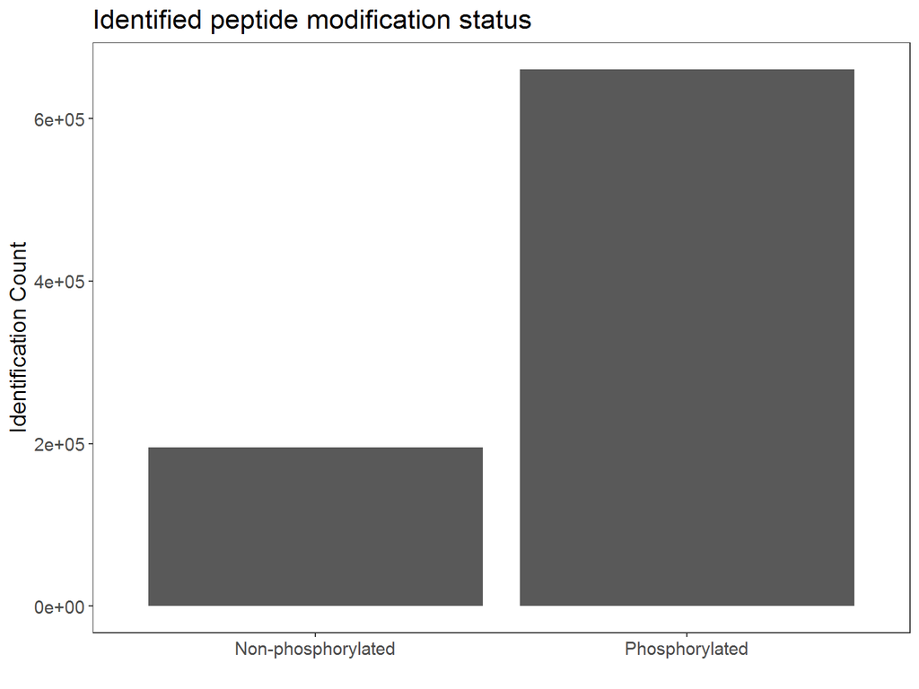

# Phosphopeptide QC stats

Mass error by intensity, AA breakdown, and phosphopeptide “multiplicity” (phosphopeptide phosphorylation count) pie and venn diagram overlay by site (AA position within the protein).

Average mass error is 0.0736808 parts per milllion. There is no strong relationship between intensity and mass error.

[figure not shown]

Breakdown of phosphosites by AA and multiplicity is as expected

[figure not shown]

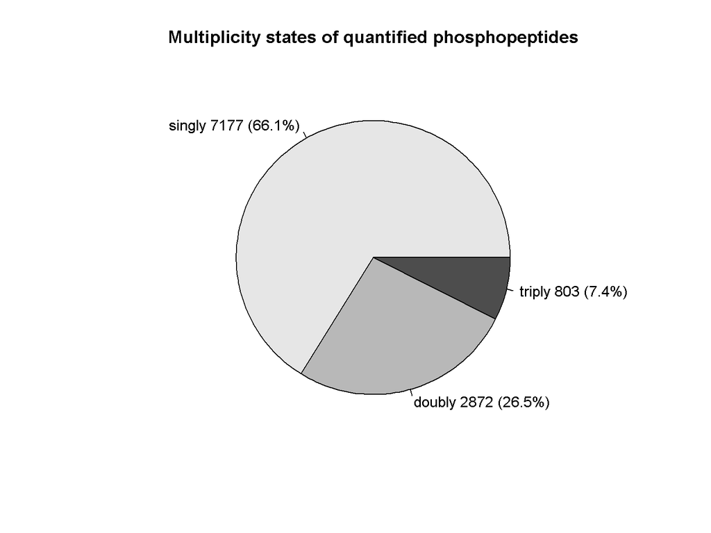

Most phosphosites are observed as singletons.

[figure not shown]

# Identification and quantification

MQ outputs a `Phospho (STY)Sites` summary table that gives all *sites* within a protein that are identified. Singly, doubly, and triply phosphorylated peptides that map/localize to this site are quantified. Class 1 sites are sites with median localiztion probability ~.95 and minimum localization probability of .75.

13143 sites were identified in at least one sample at an FDR of 1%. A breakdown of phoshposites by identification, quantification, and localization probability:

[figure not shown]

# Exploratory Data Analysis

## Boxplots & Heatmaps

7607 class 1 quantified phowphopeptides were identified in at least one sample and 42 were quantified in all samples. Log2 transform XIC Intensity values for the 95 samples. Boxplot and and pearson correlation of replicate experiments are shown below.

[figure not shown]

[interactive chart not shown]

Here are the spearman plots for the raw values.

[interactive chart not shown]

The data are median and quantile normalized.

The pairwise correlations are roughly the same following normalization.

Spearman

[interactive chart not shown]

Pearson

[interactive chart not shown]

[figure not shown]

## Outlier Detection & Removal

Finding and removing outlier samples. Note that PCA/hierarchical clustering is **Not possible without imputation**. I **would** do this but there are only 42 peptides id’d in all 95 samples…

### Coverage

Samples seem to be split into two groups, one with with fewer than 2000 identifications and another with more than 2000 identifications.

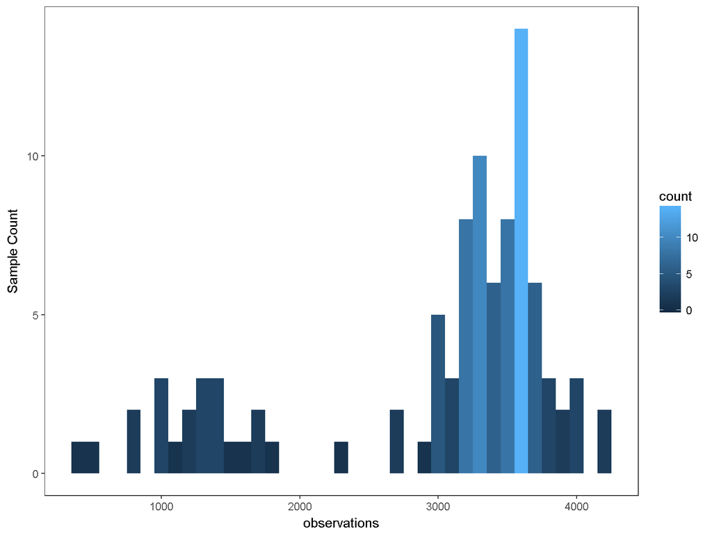

The ‘low.coverage’ ( < 2000 ids) samples are flagged and when the low coverage samples are removed the correlation acros all samples improves.

[interactive chart not shown]

However I do not want to filter purely based on coverage.

### Correlation

Most of the phosphopeptides whould not vary and the correlation accross samples should be high. Here there are many samples with median inter-sample spearman rho of < .6.

[figure not shown]

Those samples with median inter-sample spearman’s rho < .6 are flagged and removed. The heatmap of correlation obviously improves after removing such samples.

[interactive chart not shown]

### Combined Coverage and Correlation Outlier Filtering

The low correlation samples are completely subsumed by the low coverage samples. Therefore, the union of 21 low coverage and low correlation samples `coverage filtered` are filtered.

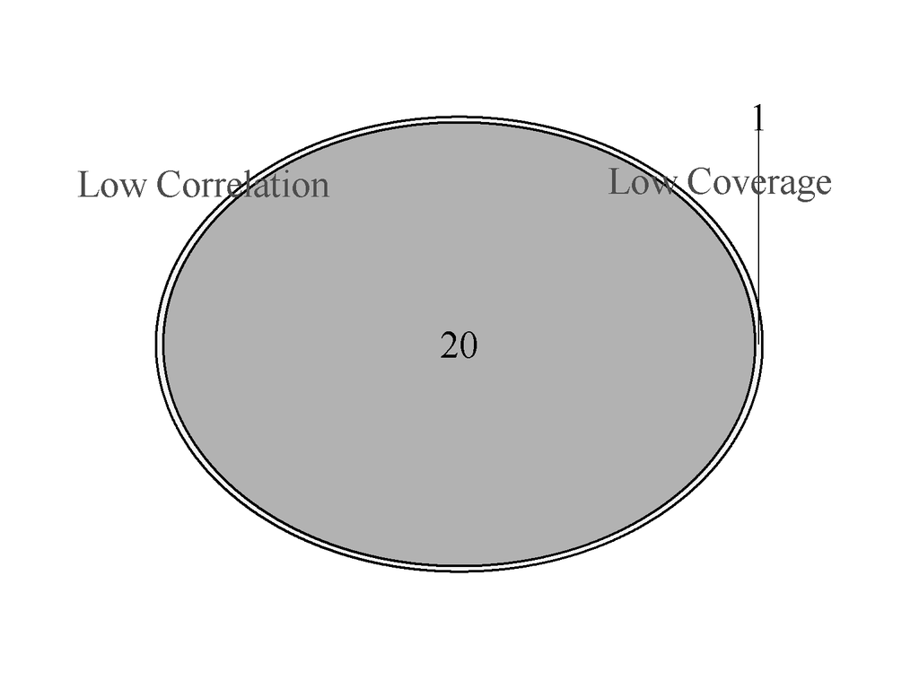

## Boxplots & Heatmaps II

Technical replicates are averaged in log2 space. Following meta-data integration, below are pearson’s correlation heatmaps and boxplots for the median and quantile normalized XICs for each phosphopeptide.Samples that have technical replicates that pass filtering show a slight deviation from median = 0.

```
## [1] TRUE
```

[figure not shown]

[interactive chart not shown]

## Principal Components Analysis

### Normalized Complete Cases

For now, I am working with phosphosites observed in all samples.

Explore variance of median & quantile normalized phosphopeptides. *This data frame is derived from measurements observed in all samples*. This plot below is calculated with **ONLY** 366 phosphopeptides. A dominant rationalizable variance ‘signature’ in this dataset is difficult to discern.

[figure not shown]

# Imputation

7607 phosphopeptides were measred in at least one. **Only 366 are truly observed in each of the samples**. Here I will impute across all samples. Imputation is cached here because I cannot manually set the random number seed.

```
## Cluster size 7546 broken into 904 6642
## Done cluster 904
## Cluster size 6642 broken into 3022 3620
## Cluster size 3022 broken into 2287 735
## Cluster size 2287 broken into 1956 331
## Cluster size 1956 broken into 1412 544
## Done cluster 1412
## Done cluster 544
## Done cluster 1956
## Done cluster 331
## Done cluster 2287
## Done cluster 735
## Done cluster 3022
## Cluster size 3620 broken into 706 2914
## Done cluster 706
## Cluster size 2914 broken into 2149 765
## Cluster size 2149 broken into 2025 124
## Cluster size 2025 broken into 477 1548
## Done cluster 477
## Cluster size 1548 broken into 463 1085
## Done cluster 463
## Done cluster 1085
## Done cluster 1548
## Done cluster 2025
## Done cluster 124
## Done cluster 2149
## Done cluster 765
## Done cluster 2914
## Done cluster 3620
## Done cluster 6642
```

## PCA of imputed data across all samples

Here, 7607 *imputed & measured* phosphopeptides are used to perform principal components analysis of the dataset. As expected, there is no dominant contributing factor.

[figure not shown]

# Model Definitions

We would like to identify differentially phosphorylated peptides between or across: 1) Donors 2) Treatments (while accounting for donor variability) 3) Times (while accounting for donor variability) 4) Treatment specific changes across times (interaction term: while accounting for donor variability)

> “All models are wrong but some are useful” - George Box

One model that only includes zeros will be used to test for differential phosphorylation across donors (#1). A generalized additive model (GAM) that uses data normalized to donor specific 0s will be used to test null hypotheses relevant to #2-#4. The first model, although it does not use all the data, benefits from the other data at the normalization and imputation steps. The second model, although it loses degrees of freedom by standardizing to zero removes the issue of confounding between time 0 and ‘untreated’. Separate heuristics will be applied to each model.

## Model I - Differences Due to Donor

Linear regression model with surrogate variables (see below) added as covariates:

$$Y_{ij} = a_i + SV_k + {\epsilon}_{ij}: i = 1,...,12;j=1,2,3;k=1,...,N$$
where $Y_{ij}$ is logged phosphosite intensity derived from the culture replicate j from individual i. $a_i$ is the estimated effect from individual i and $SV_k$ is the estimated effect from a covariate ‘surrogate variable’ k.

### Heuristic I

For ther inter-donor comparison a phosphopeptide needs to be observed in either:

1. at least 2/4 biological replicates for each donor (for more confident imputation: an anchor in every sample)
2. 4/4 biological replicates for any single donor (for missing phosphopeptides in other samples)

**3056** phosphopeptides satisfy either 1 or 2 above. The `donor.zeros.passed` and `donor.zeros.binary.passed` data frames are used for modeling. The binary data frame has the logical results of the heuristic test associated with each peptide. The peptides that do not pass the test have been removed.

## Model II - Differences Due to Treatment

For each donor a time zero estimate is calculated. The data are normalized to the donor specific zero time point. More specifically,

$$Y_{ijk} = Donor_i + Treat_j + Treat_j*S(Time_k) + {\epsilon}_{ijk}: i = 1,2,3; j=1,2; k=2.5,5,15,30,60$$

This is a GAM with one smoothing function $S(Time)$. The smoothing function used is a natural cubic spline, that is the second derivative = 0 at the boundary knots. Knots are automatically chosen at the 25th, 50th, and 75th quantiles of the data (5 15 and 30 mins here). boundary knots are at 0 and 60 min.

### Heuristic II

Due to sample processing issues, a few donors have missing samples. For the timecourse, a phosphopeptide is considered if it has **either**:

1. at least 5 observations in each treatment (half of a treatment timecourse)
2. all times (not samples) observed in a single treatment arm (half of a treatment timecourse)

1 ensures that we are using imputation results grounded by real measurements and 2 ensures we are not throwing away sites that turn on/off in specific conditions

**3931** phosphopeptides satisfy either 1 or 2 from heuristic II. The `MedianQuantiledImputedCentered.passed` and `MedianQuantiledImputedCentered.binary.passed` data frames are used for modeling. The binary data frame has the logical results of the heuristic II test associated with each peptide. The peptides that do not pass the test have been removed.

# Latent variation correction with SVA

Here I attempt to correct for unwanted latent sources of variation with **surrogate variable analysis (SVA)**, a popular form of weighted factor analysis. For the first model I have protected “donor” and for the second model I have protected the effects of time, treatment and donor using a generalized additive model (see section above for more details).

## Model I

Here I work with the `donor.zeros.passed` dataframe to identifiy factors not associated with donor.

```
## [1] TRUE
```

```
## Number of significant surrogate variables is:  3
## Iteration (out of 5 ):1  2  3  4  5
```

3 surrogate variables were identified. Below are the PCA plots before and after regressing away the surrogate variables.

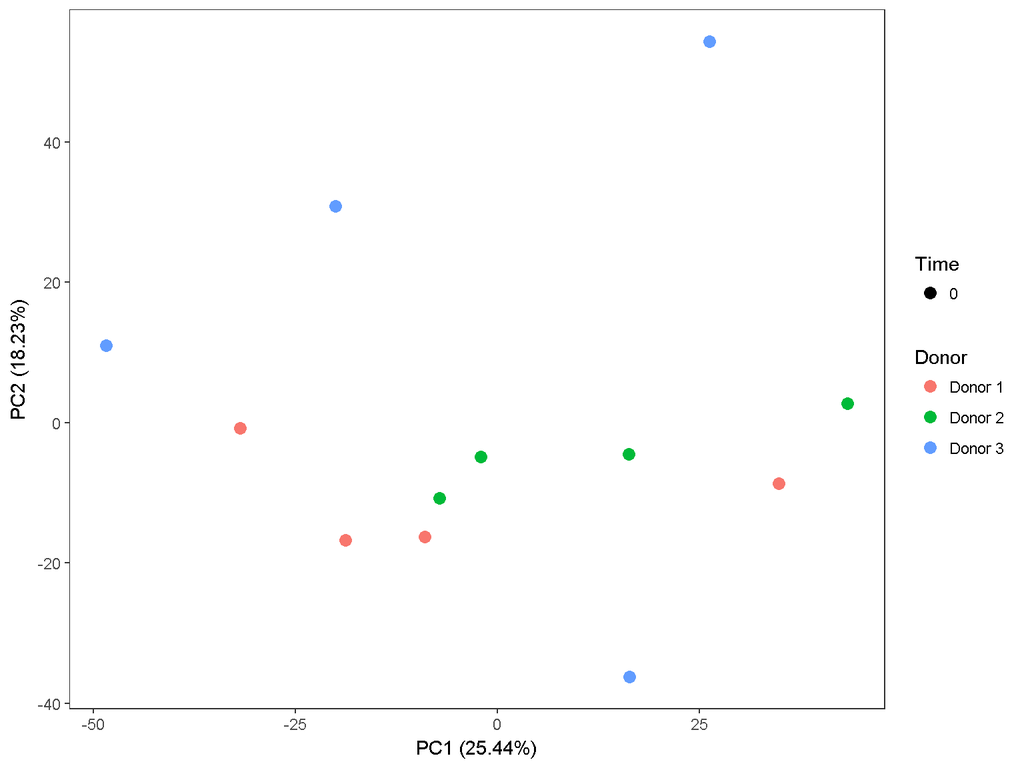

[figure not shown]

## Model II

Here I work with the `MedianQuantiledImputedCentered` dataframe to identifiy factors not associated with donor, treatment, or time within the GAM outlined above.

```
## [1] TRUE
```

```
## Number of significant surrogate variables is:  4
## Iteration (out of 5 ):1  2  3  4  5
```

4 surrogate variables were identified from the centered data. Below are the PCA plots before and after regressing away the surrogate variables. Following regression of SVs, samples cluster most prominantly by **Donor**, implying that the genetic background, or other variables confounded with ‘donor’ contribute the majority of the variation in this dataset.

[figure not shown]

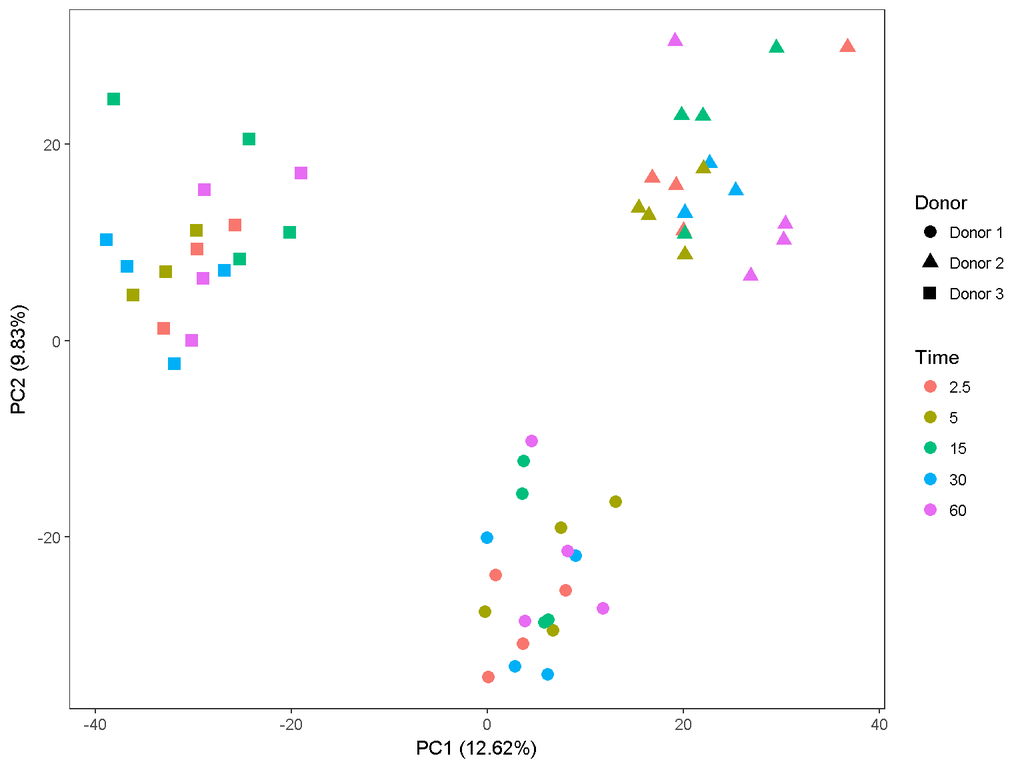

[figure not shown]

# Inference

Differential phosphorylation is performed with the `limma` framework for both models.

## Model I

Linear model of donor specific zero time points. **3056** phosphopeptides were ultimately fit to the model (see Model Definitions above). The three SVs identified above were included as covariates.

A series of EDA plots show no obvious artifacts associated with this analysis.

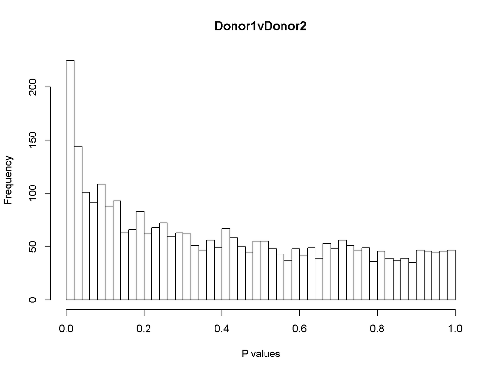

[figure not shown]

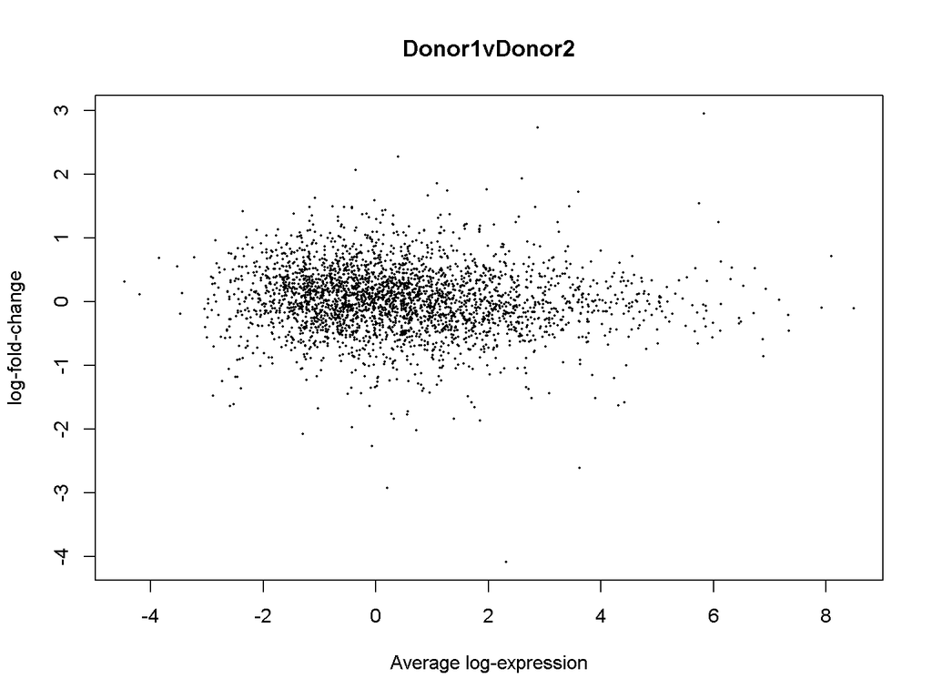

[figure not shown]

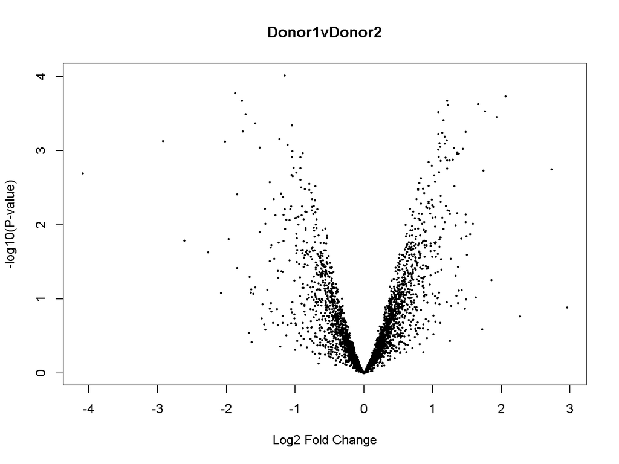

[figure not shown]

There is relatively little differential phosphorylation at an FDR of 10%. This shouldn’t be surprising given the sample processing challenges.

```
##        Donor1vDonor2 Donor2vDonor3 Donor1vDonor3
## Down              16           266           227
## NotSig          3011          2553          2562
## Up                29           237           267
```

[figure not shown]

## Model II

Three types of tests were performed:

1. Differential phosphorylation across treatments at any time
2. A significant change in phosphorylation due to time
3. A change in the time effect across treatments (interaction)

### Spline plot examples

The top hit (idmult 221_1) for within-treatment time effect (also sig difference across treatments) for ***REMOVED*** is plotted below a few different ways:

[figure not shown]

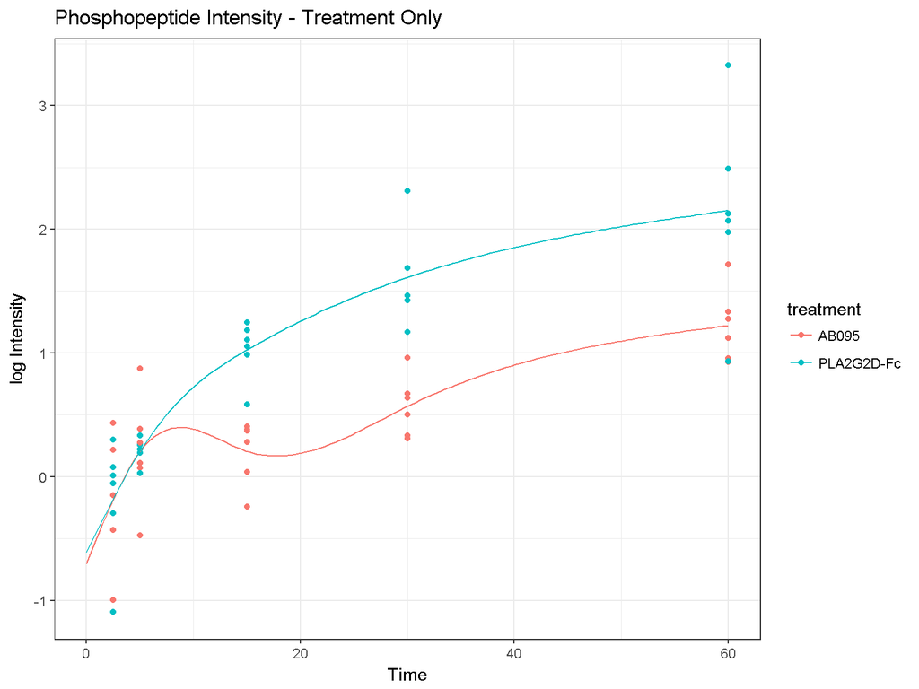

[figure not shown]

# Enrichment Analysis

Enrichments on PhosphoSitePlus kinase substrate information as well as reactome, go (bp,mf,cc), Biocarta and CORUM. Each annotation is represented at least three times in the dataset to be considered.

# Data Export

Exported:

1. The median, quantile normalized, imputed (across all samples) and SV regressed, phosphopeptide XICs for models I and II
2. The MS meta data and other identifiers associated with each site
3. A binary matrix indicating if a data point was measured (1) or imputed (0) for models I and II
4. Study meta data
5. Results from inferences tests from models I and II
6. Matrix of fitted values at each timpoint/treatment
7. Results of all enrichment analyses

Numbers 1 and 2 are combined into a single table `SiteTableCombined` where XICs with suffix **‘NormImputed’** are the above treated data. Note that the `SiteTableCombined` table has a ‘dupidmult’ column for duplicated quantifications that account for doubly or triply phosphorylated peptides mapping to mulitple sites. Numbers 3 and 4 are single tables. 4 may or may not be available.

**note that multiply phosphorylated peptides are only represented once and therefore in such cases the site of modification is not unique**

The key for annotation mergining is the ENSP identifier in the ‘protein’ column. HGNC symbols that map to protein ENSPs are sourced from biomart `mar2016.archive.ensembl.org` ensembl84 database. **note that some proteins do not have HGNCIDs mapped**